# RVPII izveštaj

Sanja Petrović E2 4/2023

2024-06-06

```r
sc <- spark_connect(master = "local")
```

## Tehnologija

Za implementaciju su korišćeni programski jezik *R* verzije 4.4.0 i alat *Apache Spark* verzije 3.5.1. Pored toga, korišćeni su i paketi `sparklyr`, `dplyr`, `ggplot2`, `ggmosaic`, `reshape2` i `corrplot`.

## Skup podataka

Skup podataka je objavljen od strane američke nacionalne agencije za javno zdravlje *Centers for Disease Control and Prevention* (*CDC*) pod nazivom *COVID-19 Case Surveillance Public Use Data with Geography* i [javno je dostupan na njihovom veb-sajtu](https://data.cdc.gov/Case-Surveillance/COVID-19-Case-Surveillance-Public-Use-Data-with-Ge/n8mc-b4w4/about_data). Svaki red predstavlja deidentifikovanog pacijenta. Skup podataka je veličine preko 14 *GB* i sadrži preko 106 miliona redova.

Izdvojene kolone:

- *case_month*: Godina i mesec slučaja, u formatu `YYYY-MM`.
- *res_state*: Savezna država u kojoj je zabeležen slučaj.
- *age_group*: Starosna grupa kojoj pripada pacijent. Moguće vrednosti: `0-17 years`, `18-49 years`, `50-64 years`, `65+ years`.
- *sex*: Pol pacijenta.
- *race*: Rasa pacijenta.
- *case_positive_specimen_interval*: Broj nedelja između najranijeg datuma i datuma prikupljanja pozitivnog uzorka.
- *case_onset_interval*: Broj nedelja između najranijeg datuma i datuma pojave prvih simptoma.
- *current_status*: Indikator da li je laboratorijski potvrđeno da je pacijent oboleo od virusa *COVID-19*.
- *symptom_status*: Indikator prisustva simptoma. Moguće vrednosti: `Asymptomatic`, `Symptomatic`.
- *hosp_yn*: Indikator da li je pacijent bio hospitalizovan.
- *icu_yn*: Indikator da li je pacijent bio primljen u odeljenje intenzivne nege.
- *death_yn*: Indikator da li je nastupio smrtni ishod.
- *underlying_conditions_yn*: Indikator da li je pacijent bolovao od drugih bolesti.

## Obrada podataka

### Priprema podataka

```r
sc <- spark_connect(master = "local")

covid.raw <- spark_read_csv(sc, name="covid", path=".")

covid.clean <- covid.raw %>%
  mutate(across(c(where(is.character)),
    ~ if_else(. == "Unknown" || . == "Missing" || . == "NA", NA, .),
    .names = "{col}"
  ))

covid.clean <- covid.clean %>%
  filter(
    !is.na(case_month) &
    !is.na(age_group) &
    !is.na(res_state) &
    current_status == "Laboratory-confirmed case"
  )
```

### Preliminarna analiza podataka

#### Deskriptivne statistike

Vrednosti deskriptivnih statistika su izračunata za obeležja *case_onset_interval* i *case_positive_specimen_interval.*

```r
sdf_describe(
  covid.clean %>% filter(case_positive_specimen_interval >= 0 & case_onset_interval >= 0),
  cols=c("case_positive_specimen_interval", "case_onset_interval")
)
```

[output not shown]

#### Vizualizovanje raspodele po pojedinačnim obeležjima

Ovaj skup podataka je ima većinski kategorijska obeležja, zbog čega su za vizualizaciju raspodele pogotovo pogodni grafici tipa *pie* ili *bar*.

##### Raspodela na osnovu pola pacijenata

Priloženi grafik nam daje uvid u to da je bilo više pacijenata ženskog pola nego muškog, kao i da postoji mali broj podataka za koje je ova vrednost nedostajuća.

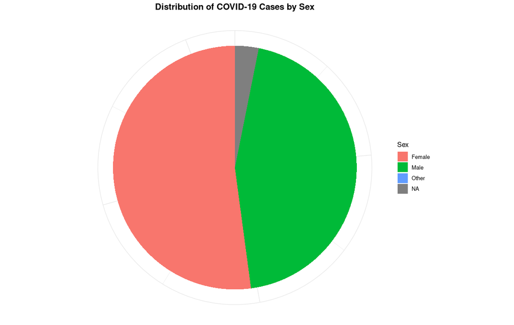

```r
ggplot(sex_data %>% collect(), aes(x = "", y = count, fill = sex)) +
  geom_bar(stat = "identity", width = 1) +
  coord_polar("y", start = 0) +
  labs(
    title = "Distribution of COVID-19 Cases by Sex",
    fill = "Sex"
  ) +
  theme_minimal() +
  theme(
    axis.title = element_blank(),
    axis.text = element_blank(),
    axis.ticks = element_blank(),
    plot.title = element_text(hjust = 0.5, size = 14, face = "bold")
  )
```

##### Raspodela na osnovu rase pacijenata

Ovim grafikom uviđamo da je najveći broj pacijenata bio bele rase, što nije iznenađujuće s obzirom na demografiju SAD. Takođe, može se primetiti da je za značajan broj pacijenata ovaj podatak nezabeležen ili sakriven.

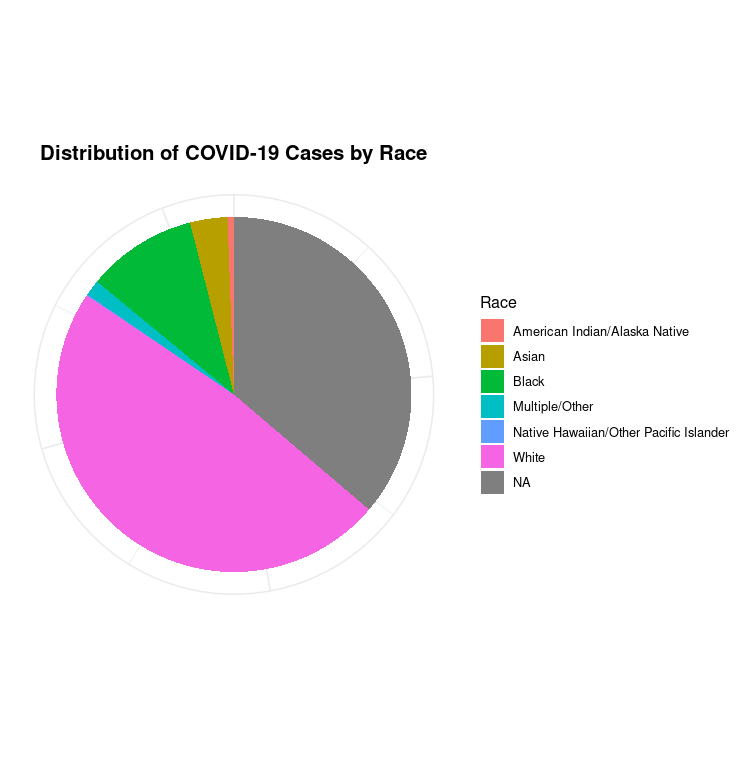

```r
ggplot(race_data %>% collect(), aes(x = "", y = count, fill = race)) +
  geom_bar(stat = "identity", width = 1) +
  coord_polar("y", start = 0) +
  labs(
    title = "Distribution of COVID-19 Cases by Race",
    fill = "Race"
  ) +
  theme_minimal() +
  theme(
    axis.title = element_blank(),
    axis.text = element_blank(),
    axis.ticks = element_blank(),
    plot.title = element_text(hjust = 0.5, size = 14, face = "bold")
  )
```

##### Raspodela na osnovu starosne grupe pacijenata

Priloženi grafik pokazuje da je bolest bila najčešća u pacijentima od 18 do 49 godina, što je i očekivano s obzirom na širi raspon godina.

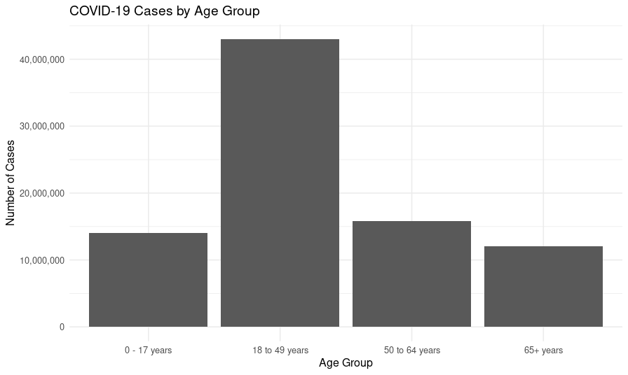

```r
ggplot(age_group_cases_df, aes(x = reorder(age_group, -case_count), y = case_count)) +
  geom_bar(stat = "identity") +
  labs(title = "COVID-19 Cases by Age Group", x = "Age Group", y = "Number of Cases") +
  theme_minimal() +
  scale_x_discrete(limits = age_group_order) +
  scale_y_continuous(labels = scales::comma)
```

#### Ispitivanje odnosa između obeležja

##### Odnos između starosne grupe i intenzivne nege

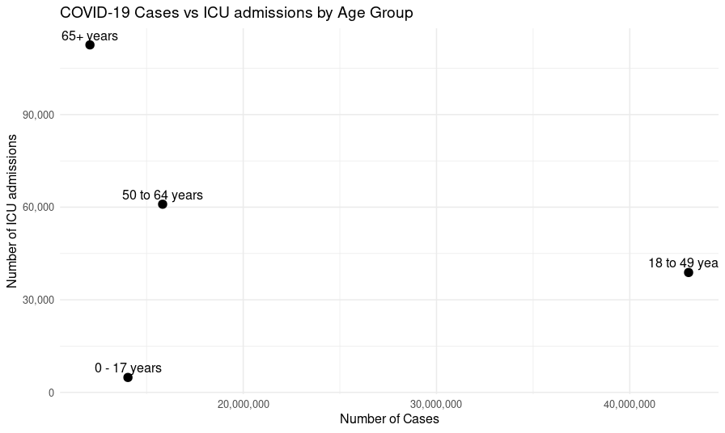

```r
ggplot(age_group_outcomes_df, aes(x = case_count, y = icu_count, label = age_group)) +
  geom_point(size = 3) +
  geom_text(vjust = -0.5, hjust = 0.5) +
  labs(title = "COVID-19 Cases vs ICU admissions by Age Group", x = "Number of Cases", y = "Number of ICU admissions") +
  theme_minimal() +
  scale_y_continuous(labels = scales::comma) +
  scale_x_continuous(labels = scales::comma)
```

##### Slučajevi kroz vreme u Kaliforniji

Ovaj grafik pruža uvid u rast i pad broja novozabeleženih slučajeva u jednoj od saveznih država.

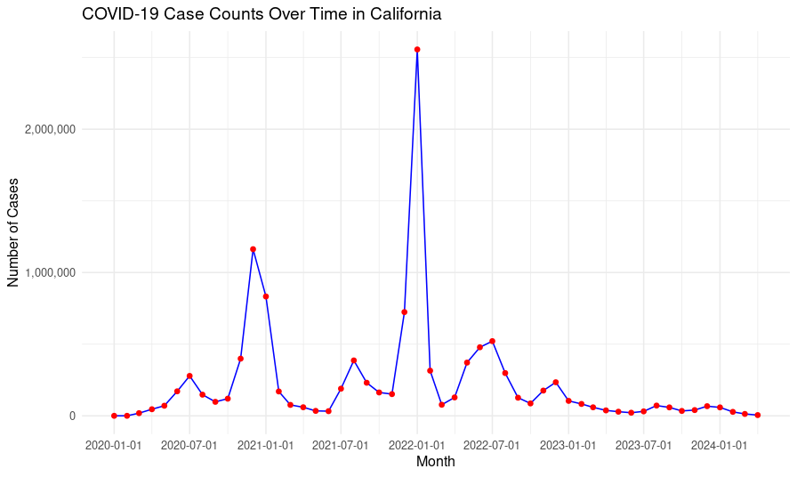

##### Ishod bolesti po starosnoj grupi i polu, procentualno

Predstavljena su dva grafika koja prikazuju razliku u ishodu bolesti između žena i muškaraca, podeljeno po starosnoj grupi. Nešto veći broj muškaraca od žena se nalazi na oba ekstrema (asimptomatičnost i smrt). Očekivano, očekivana težina bolesti raste sa porastom godina pacijenta, gde je u starosnoj grupi od preko 65 godina najveći procenat pacijenata hospitalizovan. Sa druge strane, kod najmlađih je prisutan najveći procenat pacijenata bez simptoma.

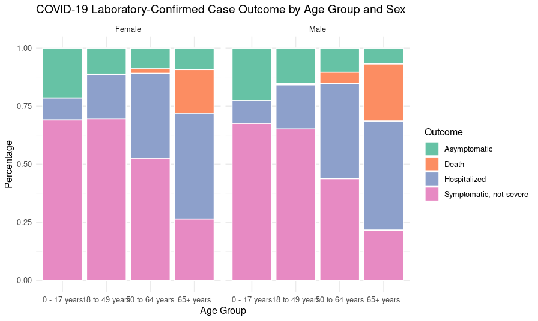

```r
covid.outcome_summary <- covid.clean %>%
  filter(
    sex %in% c("Male", "Female") &
      hosp_yn %in% c("Yes", "No") &
      death_yn %in% c("Yes", "No") &
      symptom_status %in% c("Symptomatic", "Asymptomatic")
  ) %>%
  mutate(
    outcome = case_when(
      hosp_yn == "Yes" & death_yn != "Yes" ~ "Hospitalized",
      death_yn == "Yes" ~ "Death",
      symptom_status == "Asymptomatic" ~ "Asymptomatic",
      symptom_status == "Symptomatic" & hosp_yn != "Yes" & death_yn != "Yes" & icu_yn != "Yes" ~ "Symptomatic, not severe",
      TRUE ~ "Other"
    )
  ) %>%
  filter(outcome != "Other") %>%
  group_by(age_group, sex, outcome)  %>%
  summarise(count = n(), .groups = 'drop') %>%
  group_by(age_group, sex) %>%
  mutate(percent = count / sum(count) * 100)

covid.outcome_summary_df <- collect(covid.outcome_summary)

ggplot(covid.outcome_summary_df, aes(x = age_group, y = percent, fill = outcome)) +
  geom_bar(stat = "identity", position = "fill", color = "white") +
  facet_wrap(~sex) +
  labs(title = "COVID-19 Laboratory-Confirmed Case Outcome by Age Group and Sex",
       x = "Age Group",
       y = "Percentage",
       fill = "Outcome") +
  theme_minimal() +
  scale_fill_brewer(palette = "Set2") +
  scale_x_discrete(limits = age_group_order) +
  scale_y_continuous(labels = scales::comma)
```

##### Odnos između starosne grupe, pola i broja slučajeva

Ovaj grafik prikazuje učestalost grupe pacijenata. Najveći broj pacijenata čine žene od 18 do 49 godina.

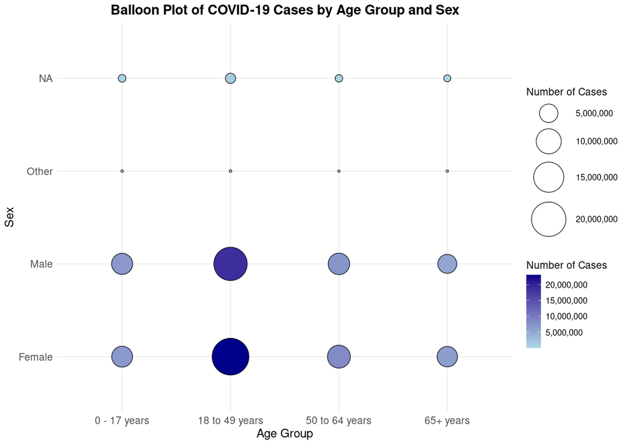

```r
ggplot(balloon_data %>% collect(), aes(x = age_group, y = sex, size = count, fill = count)) +
  geom_point(shape = 21, color = "black") +
  scale_size_continuous(range = c(1, 20), breaks = scales::pretty_breaks(n = 5), labels = scales::comma) +
  scale_fill_gradient(low = "lightblue", high = "darkblue", labels = scales::comma) +
  labs(
    title = "Balloon Plot of COVID-19 Cases by Age Group and Sex",
    x = "Age Group",
    y = "Sex",
    size = "Number of Cases",
    fill = "Number of Cases"
  ) +
  theme_minimal() +
  theme(
    plot.title = element_text(hjust = 0.5, size = 16, face = "bold"),
    axis.title = element_text(size = 14),
    axis.text = element_text(size = 12),
    legend.title = element_text(size = 12),
    legend.text = element_text(size = 10)
  )
```

##### Korelacija između starosne grupe, ishoda bolesti i ranijih bolesti

Donji grafik predstavlja korelacionu matricu za starosnu grupu, hospitalizaciju, smrtni ishod, status simptoma i prisustvo ranijih bolesti, prikazujući time njihove međusobne odnose. Ističu se određene pozitivne korelacije:

- Starosna grupa i hospitalizacija: Korelacija je 0.5, što znači da je veća verovatnoća da će stariji pacijenti biti hospitalizovani.
- Starosna grupa i smrtni ishod: Korelacija je 0.52, ukazujući na to da stariji pacijenti imaju veću verovatnoću smrtnog ishoda.
- Hospitalizacija i smrtni ishod : Korelacija je 0.46, što znači da hospitalizovani pacijenti imaju veću verovatnoću smrtnog ishoda.

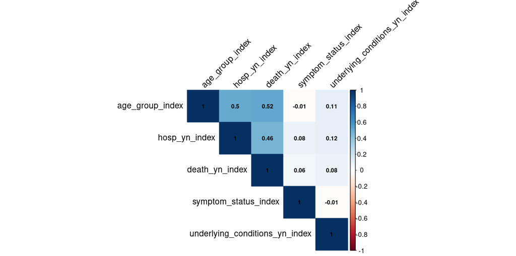

```r
covid.numeric <- covid.numeric %>%
  select(
    age_group_index,
    hosp_yn_index,
    death_yn_index,
    symptom_status_index,
    underlying_conditions_yn_index
  ) %>%
  na.omit()

covid.correlation <- cor(covid.numeric %>% collect())

corrplot(covid.correlation, method = "color", type = "upper", tl.col = "black", tl.srt = 45, addCoef.col = "black", number.cex = 0.7)
```

### Klasifikacija

#### Obeležja

Za ciljno obeležje izabrano je `death_yn`, odnosno indikator smrtnog ishoda.

Za prediktorska obeležja korišćeni su starosna grupa, pol, rasa, status simptoma, indikator hospitalizacije, indikator intenzivne nege i indikator postojećih bolesti.

```r
covid.class.formula <- death_yn ~
  age_group +
  sex +
  race +
  symptom_status +
  underlying_conditions_yn +
  hosp_yn +
  icu_yn
```

#### Metode klasifikacije

Za metode klasifikacije izabrane su logistička regresija, stabla odlučivanja i mašina potpornih vektora. Svaki metod je testiran kroz promenu parametara:

- logistička regresija i mašina potpornih vektora: variranje parametara `threshold` (0.45, 0.5, 0.55) i `max_iter` (1, 3, 10);
- stabla odlučivanja: variranje parametara `min_instances_per_node` (1, 1000, 2000) i `max_depth` (3, 5, 20).

Odrađeno je testiranje za svaku kombinaciju parametara, što čini ukupno devet scenarija.

#### Validacija

Primenjena je četvorostruka unakrsna validacija za svaki metod klasifikacije i svaku kombinaciju parametara.

#### Performanse

Za svaki metod klasifikacije i scenario, izračunate su tačnost, preciznost, osetljivost i *F1* skor, što omogućuje efikasno poređenje i uvid u najbolji izbor metoda i parametara. U priloženom kodu je primer implementacije jedne metode klasifikacije uz četvorostruku unakrsnu validaciju.

```r
k <- 4
covid.split <- covid.patients %>%
  sdf_random_split(seed=1,
                   s1=0.25,
                   s2=0.25,
                   s3=0.25,
                   s4=0.25)

covid.training <- list(
  s1 = sdf_bind_rows(covid.split$s2, covid.split$s3, covid.split$s4),
  s2 = sdf_bind_rows(covid.split$s1, covid.split$s3, covid.split$s4),
  s3 = sdf_bind_rows(covid.split$s1, covid.split$s2, covid.split$s4),
  s4 = sdf_bind_rows(covid.split$s1, covid.split$s2, covid.split$s3)
)

covid.test <- list(
  s1 = covid.split$s1,
  s2 = covid.split$s2,
  s3 = covid.split$s3,
  s4 = covid.split$s4
)
```

```r
for(i in 1:1:length(iters)) {
  covid.log.reg.trained = list(s1=ml_logistic_regression(covid.training$s1, covid.class.formula, family="binomial", threshold=ths[i], max_iter = iters[i]),
                               s2=ml_logistic_regression(covid.training$s2, covid.class.formula, family="binomial", threshold=ths[i], max_iter = iters[i]),
                               s3=ml_logistic_regression(covid.training$s3, covid.class.formula, family="binomial", threshold=ths[i], max_iter = iters[i]),
                               s4=ml_logistic_regression(covid.training$s4, covid.class.formula, family="binomial", threshold=ths[i], max_iter = iters[i])
  )

  covid.log.reg.eval.s1 <- ml_evaluate(covid.log.reg.trained$s1, covid.test$s1)
  covid.log.reg.eval.s2 <- ml_evaluate(covid.log.reg.trained$s2, covid.test$s2)
  covid.log.reg.eval.s3 <- ml_evaluate(covid.log.reg.trained$s3, covid.test$s3)
  covid.log.reg.eval.s4 <- ml_evaluate(covid.log.reg.trained$s4, covid.test$s4)

  covid.log.reg.accuracy[[i]] <- (covid.log.reg.eval.s1$accuracy() + covid.log.reg.eval.s2$accuracy() + covid.log.reg.eval.s3$accuracy() + covid.log.reg.eval.s4$accuracy()) / k
  covid.log.reg.prec[[i]] <- (covid.log.reg.eval.s1$weighted_precision() + covid.log.reg.eval.s2$weighted_precision() + covid.log.reg.eval.s3$weighted_precision() + covid.log.reg.eval.s4$weighted_precision()) / k
  covid.log.reg.f1[[i]] <- (covid.log.reg.eval.s1$weighted_f_measure() + covid.log.reg.eval.s2$weighted_f_measure() + covid.log.reg.eval.s3$weighted_f_measure() + covid.log.reg.eval.s4$weighted_f_measure()) / k
  covid.log.reg.recall[[i]] <- (covid.log.reg.eval.s1$weighted_recall() + covid.log.reg.eval.s2$weighted_recall() + covid.log.reg.eval.s3$weighted_recall() + covid.log.reg.eval.s4$weighted_recall()) / k
}
```

##### Logistička regresija

Na datim graficima je prikazana zavisnost tačnosti, preciznosti, osetljivosti i *F1* skora od broja iteracija i praga.

```r
ggplot(data, aes(x = iter, y = accuracy, color = as.factor(th))) +
  geom_point(size=4, position = position_jitter(width = 0.15, height = 0), alpha = 0.6) +
  scale_x_continuous(breaks = c(1, 3, 10)) +
  scale_color_manual(values = c("red", "blue", "green")) +
  labs(title = "Logistic Regression Accuracy Over Iterations and Thresholds",
       x = "Iteration",
       y = "Accuracy",
       color = "Threshold") +
  theme_minimal()
```

```r
ggplot(data, aes(x = iter, y = precision, color = as.factor(th))) +
  geom_point(size=4, position = position_jitter(width = 0.15, height = 0), alpha = 0.6) +
  scale_x_continuous(breaks = c(1, 3, 10)) +
  scale_color_manual(values = c("red", "blue", "green")) +
  labs(title = "Logistic Regression Precision Over Iterations and Thresholds",
       x = "Iteration",
       y = "Precision",
       color = "Threshold") +
  theme_minimal()
```

```r
ggplot(data, aes(x = iter, y = recall, color = as.factor(th))) +
  geom_point(size=4, position = position_jitter(width = 0.15, height = 0), alpha = 0.6) +
  scale_x_continuous(breaks = c(1, 3, 10)) +
  scale_color_manual(values = c("red", "blue", "green")) +
  labs(title = "Logistic Regression Recall Over Iterations and Thresholds",
       x = "Iteration",
       y = "Recall",
       color = "Threshold") +
  theme_minimal()
```

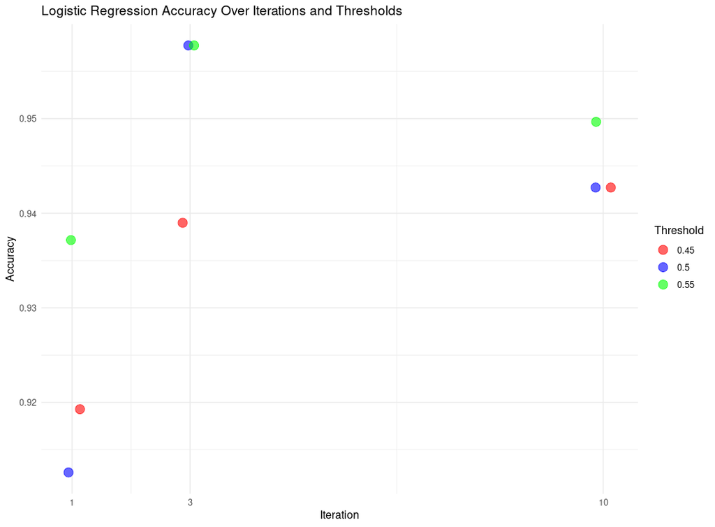

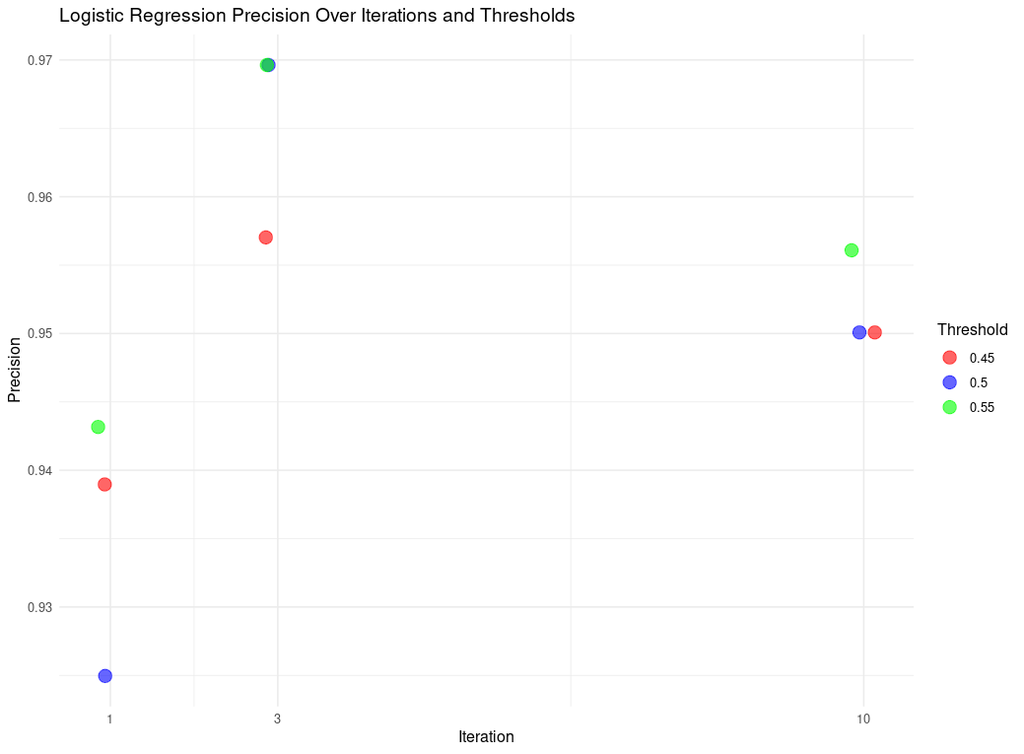

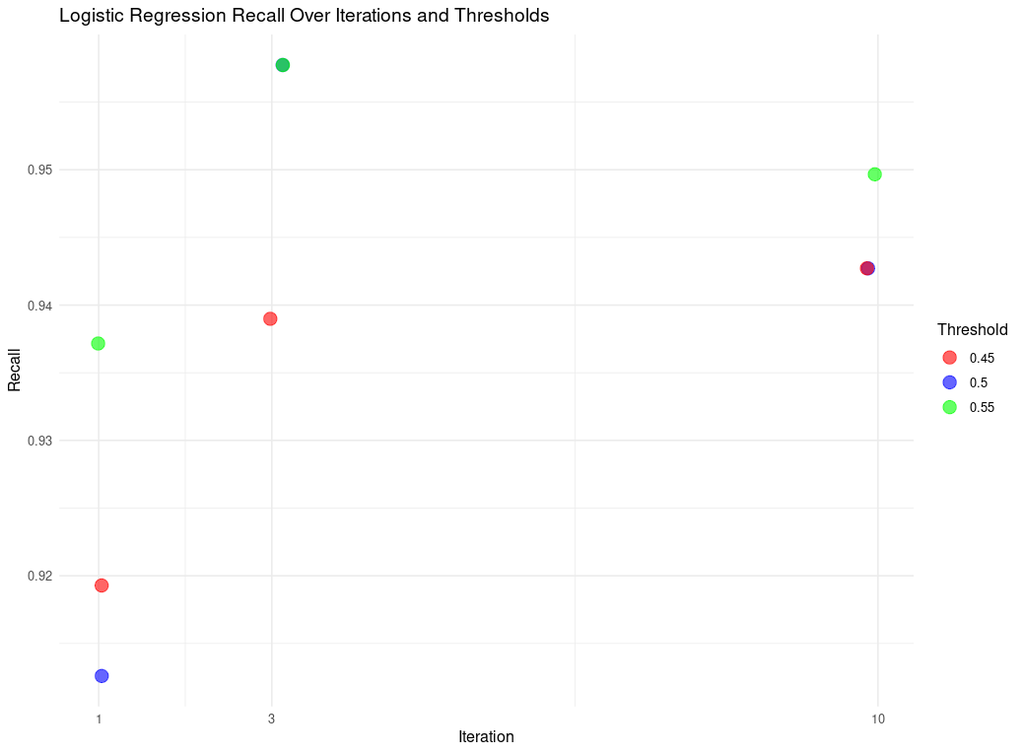

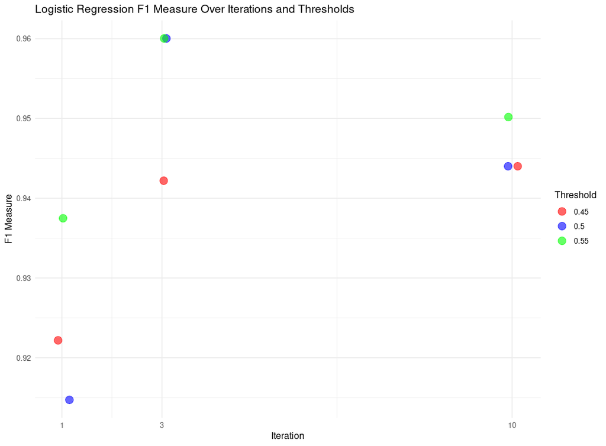

```r
ggplot(data, aes(x = iter, y = f1, color = as.factor(th))) +
  geom_point(size=4, position = position_jitter(width = 0.15, height = 0), alpha = 0.6) +
  scale_x_continuous(breaks = c(1, 3, 10)) +
  scale_color_manual(values = c("red", "blue", "green")) +
  labs(title = "Logistic Regression F1 Measure Over Iterations and Thresholds",
       x = "Iteration",
       y = "F1 Measure",
       color = "Threshold") +
  theme_minimal()
```

##### Stabla odlučivanja

```r
ggplot(data, aes(x = depth, y = accuracy, color = as.factor(inst))) +
  geom_point(size=4, position = position_jitter(width = 0.15, height = 0), alpha = 0.6) +
  scale_x_continuous(breaks = c(3, 5, 20)) +
  scale_color_manual(values = c("red", "blue", "green")) +
  labs(title = "Decision Tree Accuracy Over Min Instances Per Node and Max Depth",
       x = "Depth",
       y = "Accuracy",
       color = "Min Instances Per Node") +
  theme_minimal()
```

```r
ggplot(data, aes(x = depth, y = accuracy, color = as.factor(inst))) +
  geom_point(size=4, position = position_jitter(width = 0.15, height = 0), alpha = 0.6) +
  scale_x_continuous(breaks = c(3, 5, 20)) +
  scale_color_manual(values = c("red", "blue", "green")) +
  labs(title = "Decision Tree Precision Over Min Instances Per Node and Max Depth",
       x = "Depth",
       y = "Precision",
       color = "Min Instances Per Node") +
  theme_minimal()
```

```r
ggplot(data, aes(x = depth, y = accuracy, color = as.factor(inst))) +
  geom_point(size=4, position = position_jitter(width = 0.15, height = 0), alpha = 0.6) +
  scale_x_continuous(breaks = c(3, 5, 20)) +
  scale_color_manual(values = c("red", "blue", "green")) +
  labs(title = "Decision Tree Recall Over Min Instances Per Node and Max Depth",
       x = "Depth",
       y = "Recall",
       color = "Min Instances Per Node") +
  theme_minimal()
```

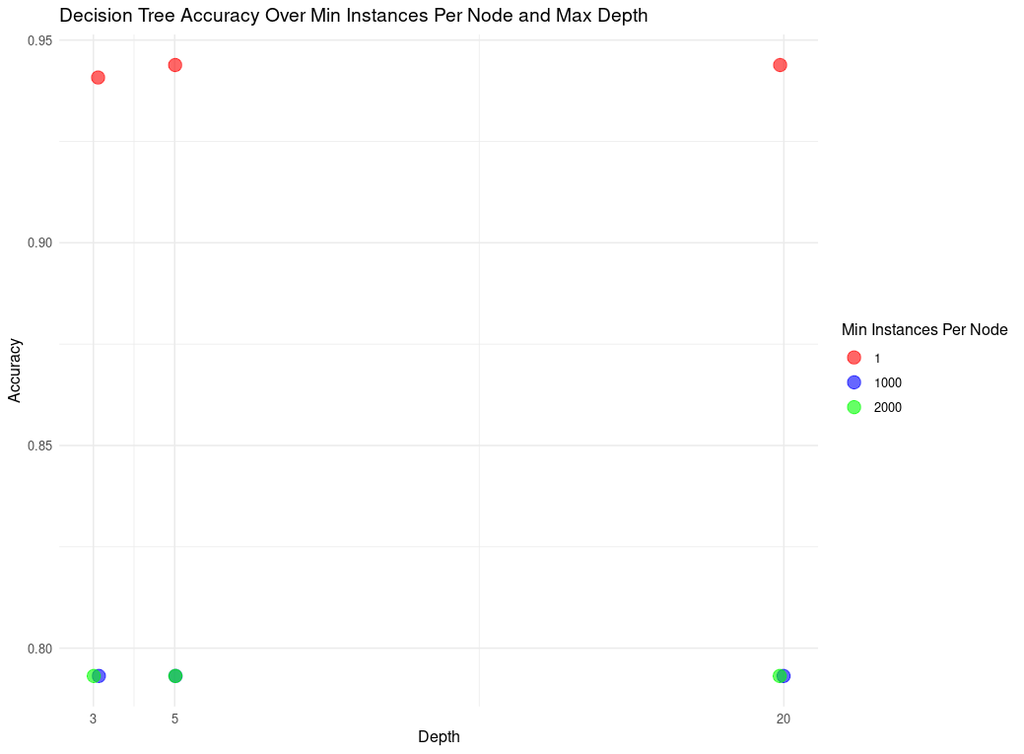

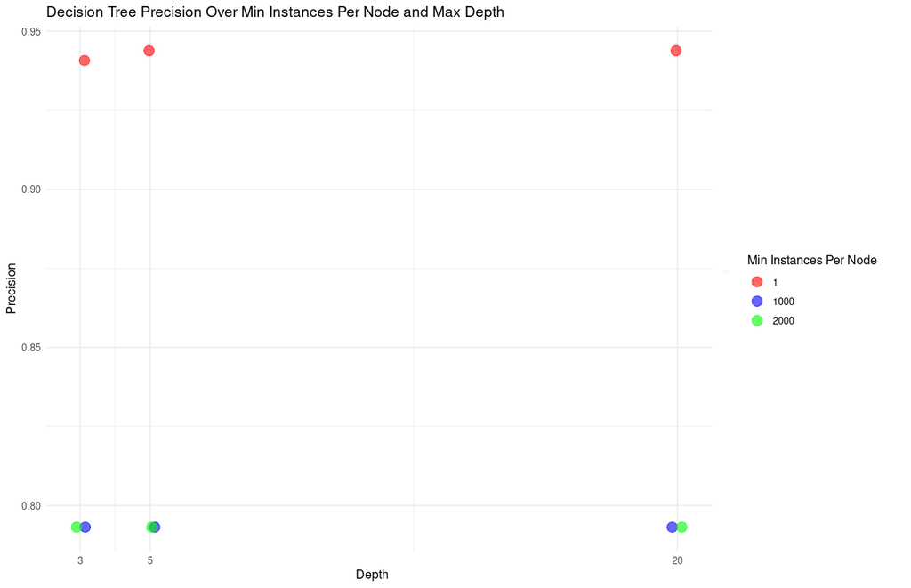

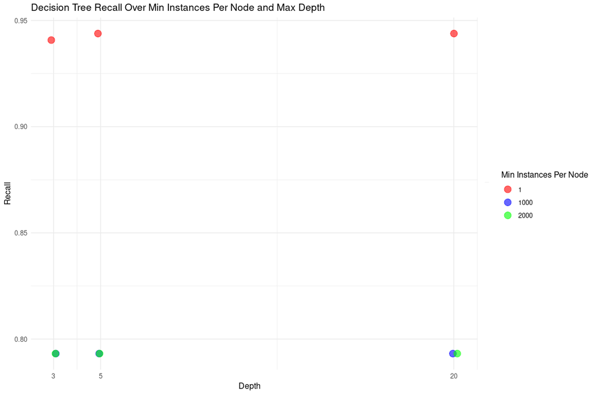

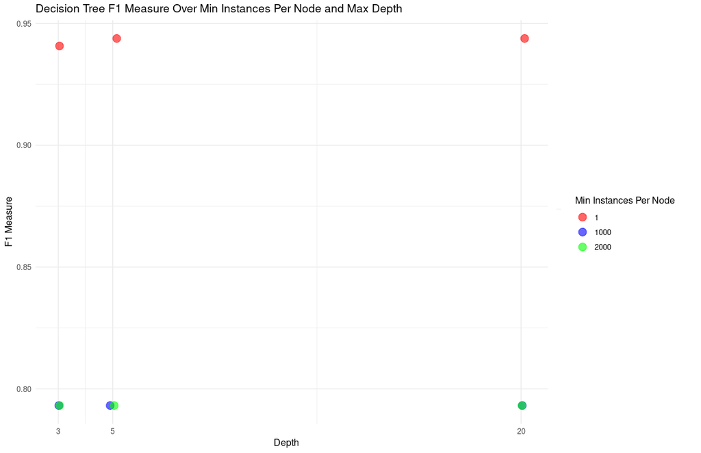

```r
ggplot(data, aes(x = depth, y = accuracy, color = as.factor(inst))) +
  geom_point(size=4, position = position_jitter(width = 0.15, height = 0), alpha = 0.6) +
  scale_x_continuous(breaks = c(3, 5, 20)) +
  scale_color_manual(values = c("red", "blue", "green")) +
  labs(title = "Decision Tree F1 Measure Over Min Instances Per Node and Max Depth",
       x = "Depth",
       y = "F1 Measure",
       color = "Min Instances Per Node") +
  theme_minimal()
```

##### Mašina potpornih vektora

Na datim graficima je prikazana zavisnost tačnosti, preciznosti, osetljivosti i *F1* skora od broja iteracija i praga.

Najbolja tačnost je u scenariju od 10 iteracija i pragova 0.55 ili 0.45, dok je preciznost bila bolja sa jednom iteracijom i pragom 0.5. Osetljivost je bolja sa 3 ili 10 maksimalnih iteracija, a *F1* skor je bio najbolji sa 10 maksimalnih iteracija.

```r
data <- data.frame(iter = iters, th = ths, accuracy = unlist(covid.svm.accuracy), precision = unlist(covid.svm.prec), recall = unlist(covid.svm.recall), f1 = unlist(covid.svm.f1))
ggplot(data, aes(x = iter, y = accuracy, color = as.factor(th))) +
  geom_point(size=4, position = position_jitter(width = 0.15, height = 0), alpha = 0.6) +
  scale_x_continuous(breaks = c(1, 3, 10)) +
  scale_color_manual(values = c("red", "blue", "green")) +
  labs(title = "Support Vector Machine Accuracy Over Iterations and Thresholds",
       x = "Iteration",
       y = "Accuracy",
       color = "Threshold") +
  theme_minimal()
```

```r
ggplot(data, aes(x = iter, y = precision, color = as.factor(th))) +
  geom_point(size=4, position = position_jitter(width = 0.15, height = 0), alpha = 0.6) +
  scale_x_continuous(breaks = c(1, 3, 10)) +
  scale_color_manual(values = c("red", "blue", "green")) +
  labs(title = "Support Vector Machine Precision Over Iterations and Thresholds",
       x = "Iteration",
       y = "Precision",
       color = "Threshold") +
  theme_minimal()
```

```r
ggplot(data, aes(x = iter, y = recall, color = as.factor(th))) +
  geom_point(size=4, position = position_jitter(width = 0.15, height = 0), alpha = 0.6) +
  scale_x_continuous(breaks = c(1, 3, 10)) +
  scale_color_manual(values = c("red", "blue", "green")) +
  labs(title = "Support Vector Machine Recall Over Iterations and Thresholds",
       x = "Iteration",
       y = "Recall",
       color = "Threshold") +
  theme_minimal()
```

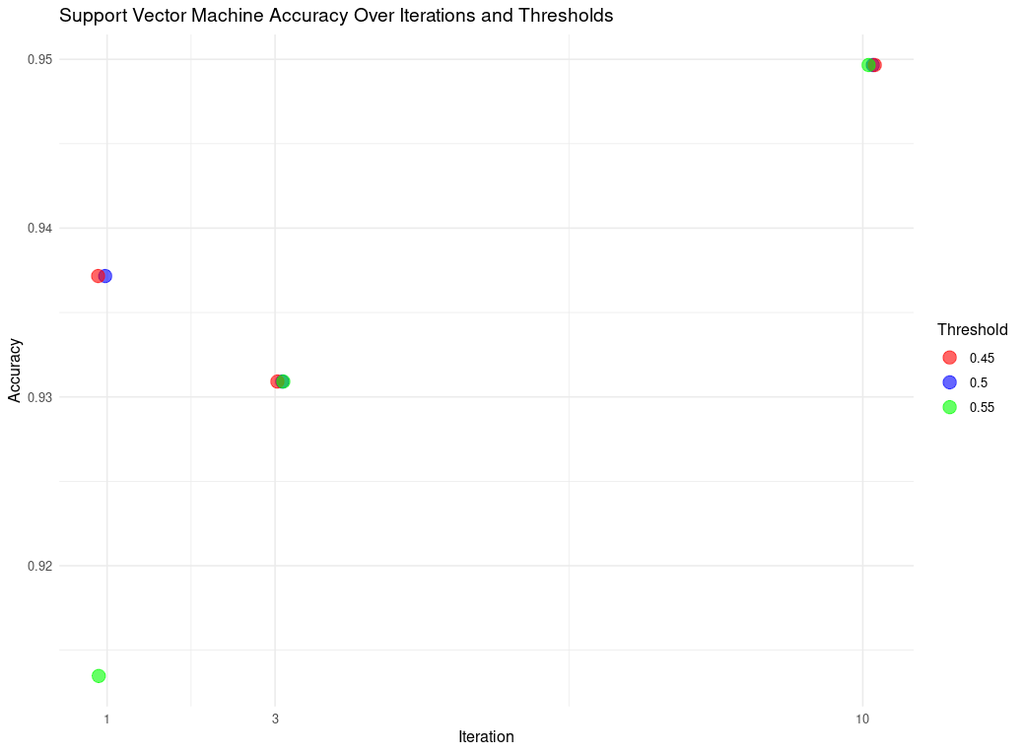

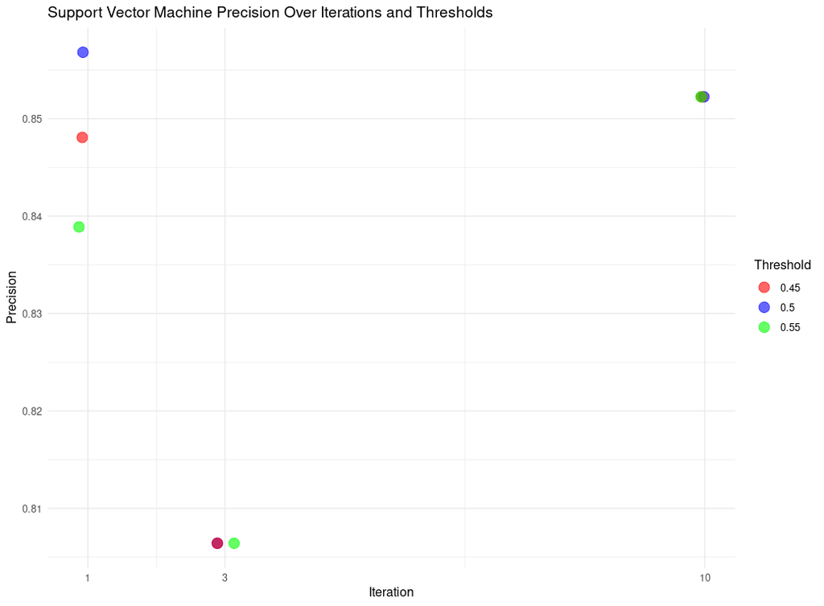

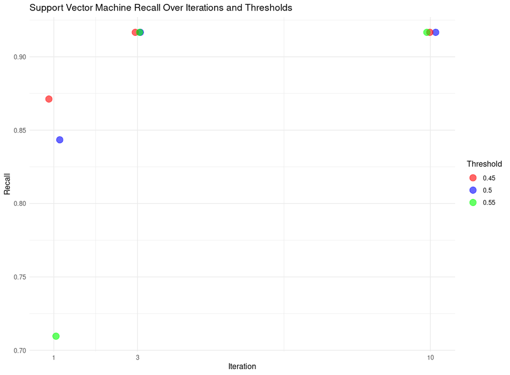

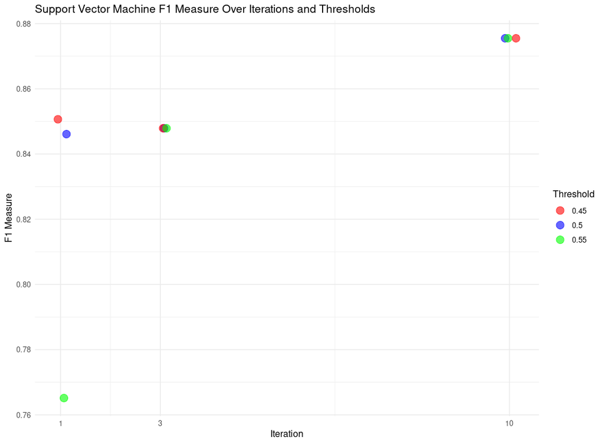

```r
ggplot(data, aes(x = iter, y = f1, color = as.factor(th))) +
  geom_point(size=4, position = position_jitter(width = 0.15, height = 0), alpha = 0.6) +
  scale_x_continuous(breaks = c(1, 3, 10)) +
  scale_color_manual(values = c("red", "blue", "green")) +
  labs(title = "Support Vector Machine F1 Measure Over Iterations and Thresholds",
       x = "Iteration",
       y = "F1 Measure",
       color = "Threshold") +
  theme_minimal()
```

Ukupno, najbolje rezultate po svim parametrima daje logistička regresija sa tri iteracije i pragovima 0.5 ili 0.55.

### Klasterizacija

Cilj klasterizacije je ispitivanje odnosa broja smrti i starosne grupe pacijenta.

##### Priprema podataka

```r
covid.clustering.data <- covid.clean %>%
  mutate(age_group_index = case_when(
    age_group == "0 - 17 years" ~ 0,
    age_group == "18 to 49 years" ~ 1,
    age_group == "50 to 64 years"~ 2,
    age_group == "65+ years" ~ 3,
    TRUE ~ NA_real_
  )) %>%
  select(age_group_index, sex, race, case_month, res_state, death_yn) %>%
  na.omit()

covid.clustering.data <- covid.clustering.data %>%
  group_by(age_group_index, sex, case_month, res_state, race) %>%
  summarise(death_count = sum(ifelse(death_yn == TRUE, 1, 0), na.rm = TRUE), .groups = "keep")
```

##### K-Means, `k = 7`, `max_iter = 3`

```r
covid.clustering.data.kmeans <- covid.clustering.data %>%
  ml_kmeans(~ age_group_index + death_count,
            k = 7,
            max_iter = 3,
            init_mode = "k-means||")
```

Na grafiku ispod su prikazani dobijeni klasteri sa svojim centrima. Može se uočiti broj umrlih raste sa povećanjem starosne grupe.

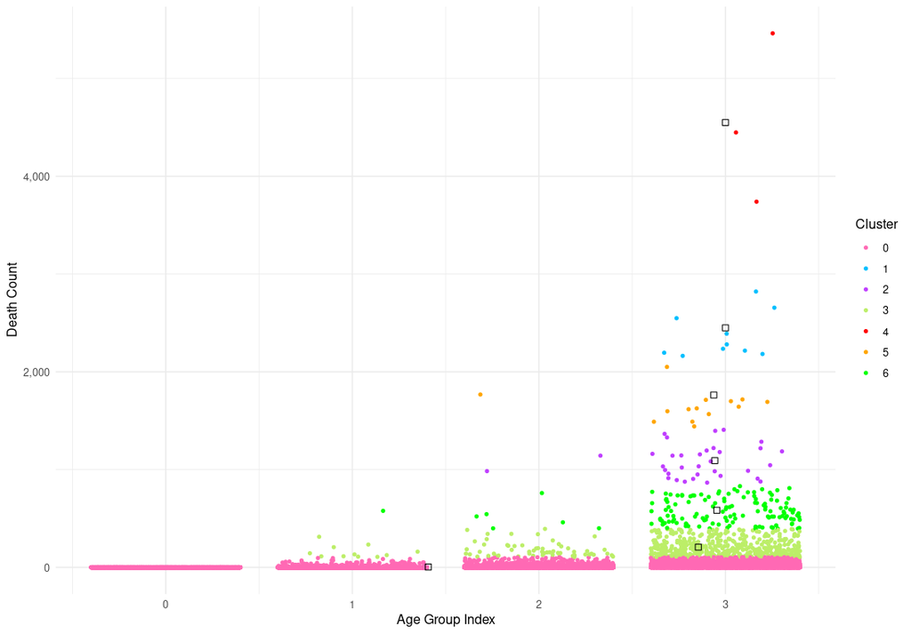

```r
cluster.centers.df <- data.frame(covid.clustering.data.kmeans$centers)
ggplot(data = covid.clustering.data,
       aes(x = age_group_index, y = death_count, colour = clust)) +
  geom_jitter(size = 1) +
  geom_point(data = cluster.centers.df,
             color = "black",
             size = 2,
             shape = 0 )+
  theme_minimal() +
  labs(
    y = "Death Count",
    x = "Age Group Index",
    color = "Cluster"
  ) +
  scale_y_continuous(labels = scales::comma) +
  scale_x_continuous(labels = scales::comma) +
  scale_color_manual(values = c("hotpink", "deepskyblue", "darkorchid1", "darkolivegreen2", "red", "orange", "green"))
```

Strukturu klastera možemo dodatno analizirati na osnovu sledećih grafika koji prikazuju prosečnu starost i prosečnu smrtnost po klasteru.

```r
cluster_analysis <- covid.clustering.data %>%
  group_by(clust) %>%
  summarise(
    avg_death_count = mean(death_count, na.rm = TRUE),
    avg_age_group_index = mean(age_group_index, na.rm = TRUE),
    count = n()
  )
```

```r
ggplot(cluster_analysis, aes(x = clust, y = avg_age_group_index, fill = clust)) +
  geom_bar(stat = "identity") +
  labs(title = "Average Age Group Index per Cluster",
       x = "Cluster",
       y = "Average Age Group Index") +
  theme_minimal() +
  theme(legend.position = "none") +
  scale_fill_manual(values = c("hotpink", "deepskyblue", "darkorchid1", "darkolivegreen2", "red", "orange", "green"))
```

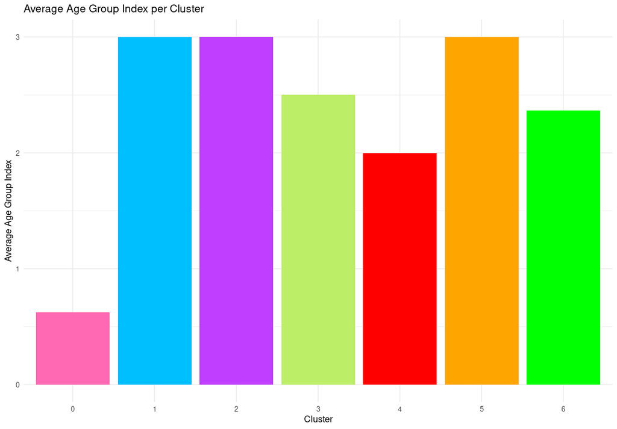

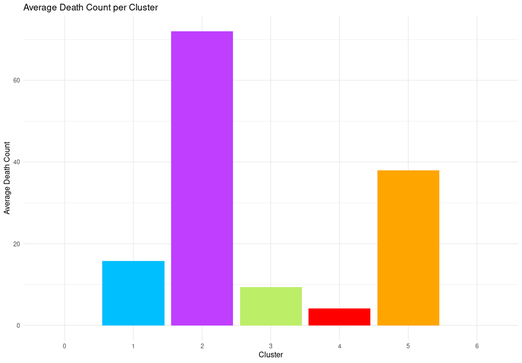

```r
ggplot(cluster_analysis, aes(x = clust, y = avg_death_count, fill = clust)) +
  geom_bar(stat = "identity") +
  labs(title = "Average Death Count per Cluster",
       x = "Cluster",
       y = "Average Death Count") +
  theme_minimal() +
  theme(legend.position = "none") +
  scale_fill_manual(values = c("hotpink", "deepskyblue", "darkorchid1", "darkolivegreen2", "red", "orange", "green"))
```

Na osnovu ovih grafika, možemo uočiti očigledne grupe pacijenata, zavisno od kombinacije godina i smrtnosti. Naime, ističe se drugi klaster koji ima najveću stopu smrtnosti i najveću prosečnu starost, kao i nulti klaster koji ima najmanju stopu smrtnosti i najmanju prosečnu starost.

Raspodela entiteta po klasterima je prikazana na sledećem grafiku.

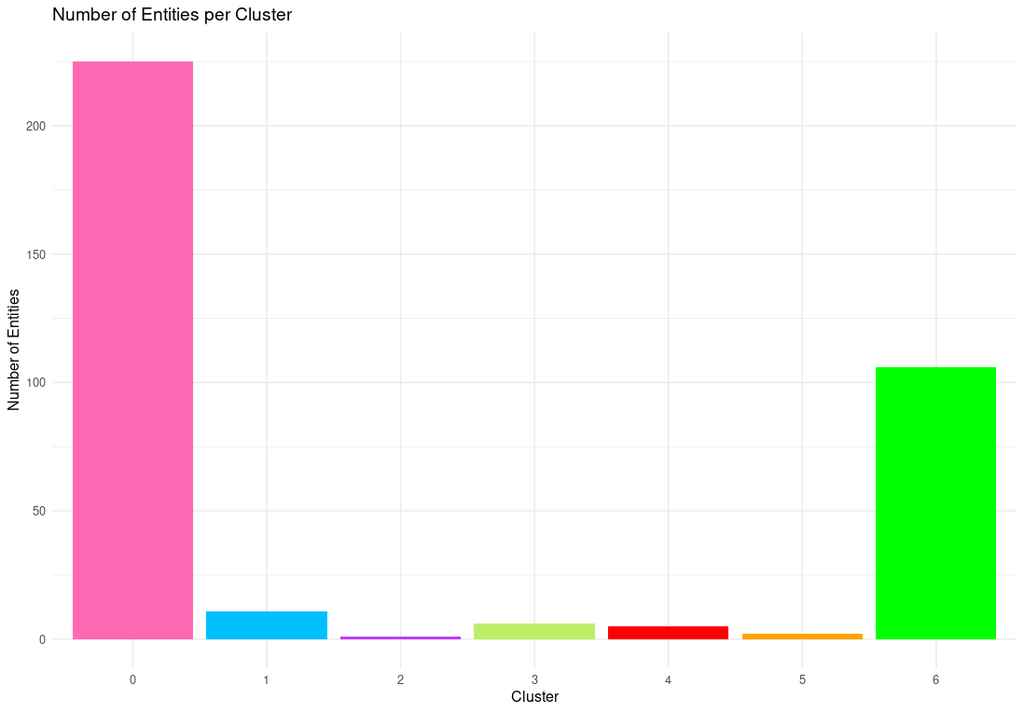

```r
ggplot(cluster_analysis, aes(x = clust, y = count, fill = clust)) +
  geom_bar(stat = "identity") +
  scale_fill_manual(values = c("hotpink", "deepskyblue", "darkorchid1", "darkolivegreen2", "red", "orange", "green")) +
  labs(title = "Number of Entities per Cluster",
       x = "Cluster",
       y = "Number of Entities") +
  theme_minimal() +
  theme(legend.position = "none")
```